# Stats 506, F18, Group Project

Ruirui Zhang, ruiruiz@umich.edu

# Summarize Data

The dataset we used in this project was [meatspec](https://cran.r-project.org/web/packages/faraway/faraway.pdf), from R package: faraway.

The dataset has 215 rows and 101 columns. Each of 215 rows represent one sample. For each sample, the fat content of fresh choped meat was measured along the 100 channel spectrum of absorbances. Among the 101 columns, the first 100 columns represent the absorbances across a range of 100 wavelengths, and the last column represents the fat content.

Since determining the fat content via analytical chemistry is time consuming we would like to build a model to predict the fat content of new samples using 100 obsorbances which can be measured more easily.

```
library(faraway)
```

[output not shown]

```
X = as.matrix(meatspec[, -101])
e = eigen(t(X) %*% X)$val
max(e)/min(e) # 2.6e+14
```

```
## [1] 2.613081e+14
```

Below is a plot of correlation among 100 channel spectrum of absorbances. We observe very high collinearity, where adjacent channels are almost perfectly correlated.

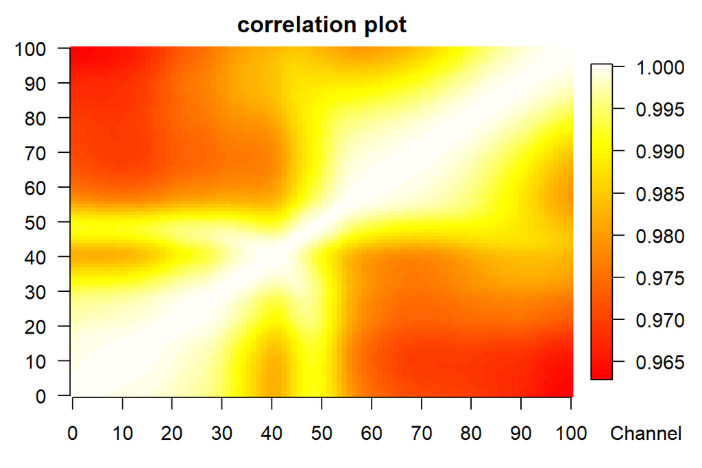